# Team Report

Felix Baez-Santiago, Chris Anderson, Austin Nebel

2/17/2021

```r
#importing dataset from web scrap
choco <- read.csv("https://raw.githubusercontent.com/xdaiISU/ds202materials/master/hwlabs/data/choco.csv")
str(choco)
```

```
## 'data.frame':    2312 obs. of  13 variables:
##  $ REF                 : int  2454 2458 2454 797 797 1015 1019 1011 1019 1011 ...
##  $ Company             : chr  "5150" "5150" "5150" "A. Morin" ...
##  $ Location            : chr  "U.S.A." "U.S.A." "U.S.A." "France" ...
##  $ Date                : int  2019 2019 2019 2012 2012 2013 2013 2013 2013 2013 ...
##  $ Bean_Origin         : chr  "Madagascar" "Dominican Republic" "Tanzania" "Peru" ...
##  $ Specific_Bean_Origin: chr  "Bejofo Estate, batch 1" "Zorzal, batch 1" "Kokoa Kamili, batch 1" "Peru" ...
##  $ Cocoa_Percent       : num  76 76 76 63 70 70 63 70 70 70 ...
##  $ Ingredients         : chr  "3- B,S,C" "3- B,S,C" "3- B,S,C" "4- B,S,C,L" ...
##  $ Characteristics1    : chr  "cocoa" "cocoa" "rich cocoa" "fruity" ...
##  $ Characteristics2    : chr  "blackberry" "vegetal" "fatty" "melon" ...
##  $ Characteristics3    : chr  "full body" "savory" "bready" "roasty" ...
##  $ Characteristics4    : chr  NA NA NA NA ...
##  $ Rating              : num  3.75 3.5 3.25 3.75 3.5 4 4 3.75 3.5 3.25 ...
```

# Question 1.1

How are the ratings distributed? Create both a histogram and a boxplot and describe them. Don’t forget to mention outliers, if there are any.

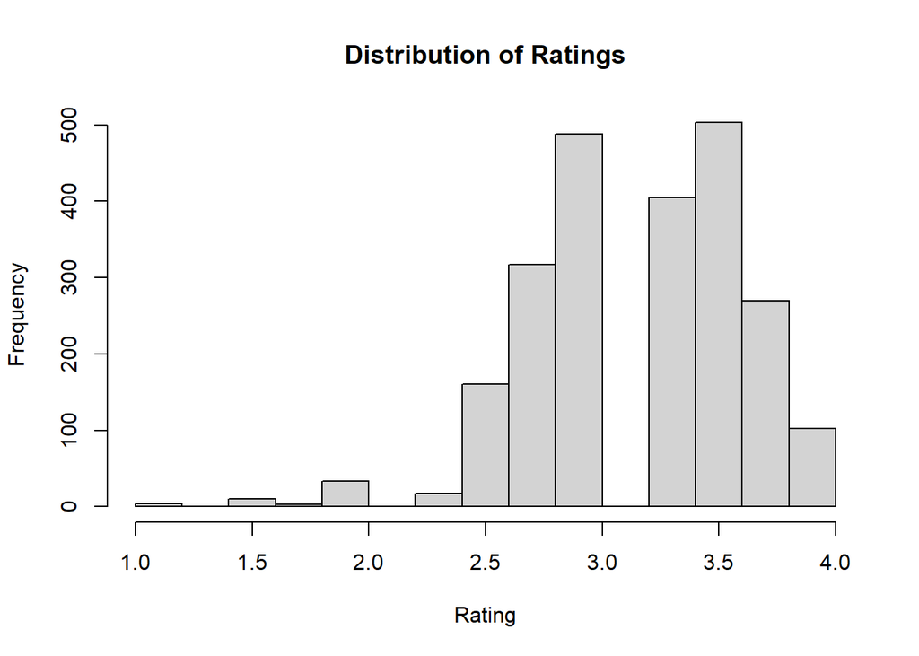

```r
hist(choco$Rating, main='Distribution of Ratings', xlab='Rating')
```

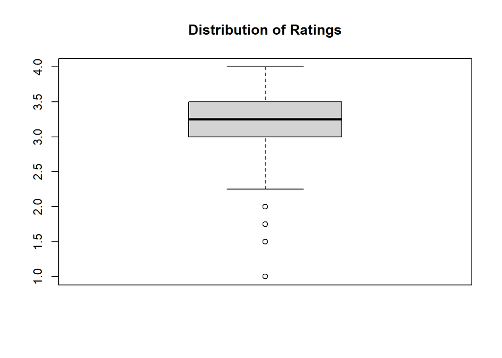

```r
boxplot(choco$Rating, main='Distribution of Ratings')
```

The rating distribution is bimodal, left skewed, most of the data is in between 2.5 and 4.0 with an extreme gap in the the middle and there are at least 4 outliers present.

# Question 1.2

How does the number of ratings depend on the location of the company? Draw a bar chart of the number of reports.

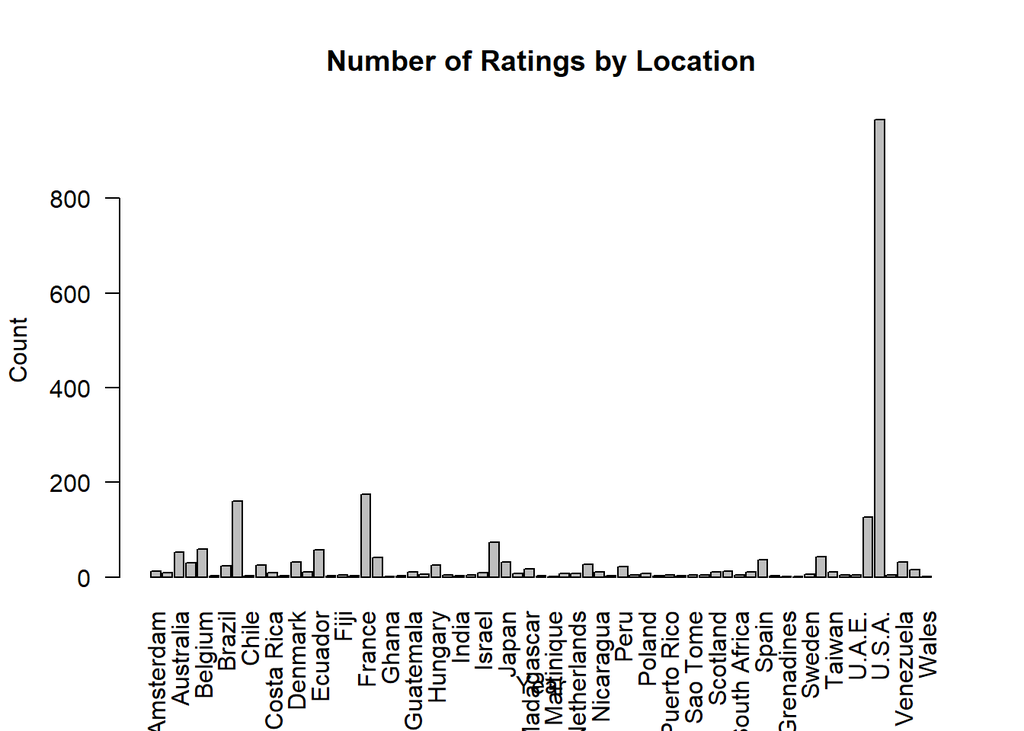

```r
barplot(table(choco$Location), main='Number of Ratings by Location', xlab='Year', ylab='Count', las  = 2)
```

```r
# text(x = table(choco$location), labels = names(choco$location), srt = 45, xpd = Na)
```

# Question 1.3

Do ratings depend on the cocoa percentage of a chocolate bar? Create both numerical and graphical summaries, and explain. [Hint: Think about why the scatterplot is not a very good choice for visualization here.]

```r
cor(choco$Rating, choco$Cocoa_Percent)
```

```
## [1] -0.1510178
```

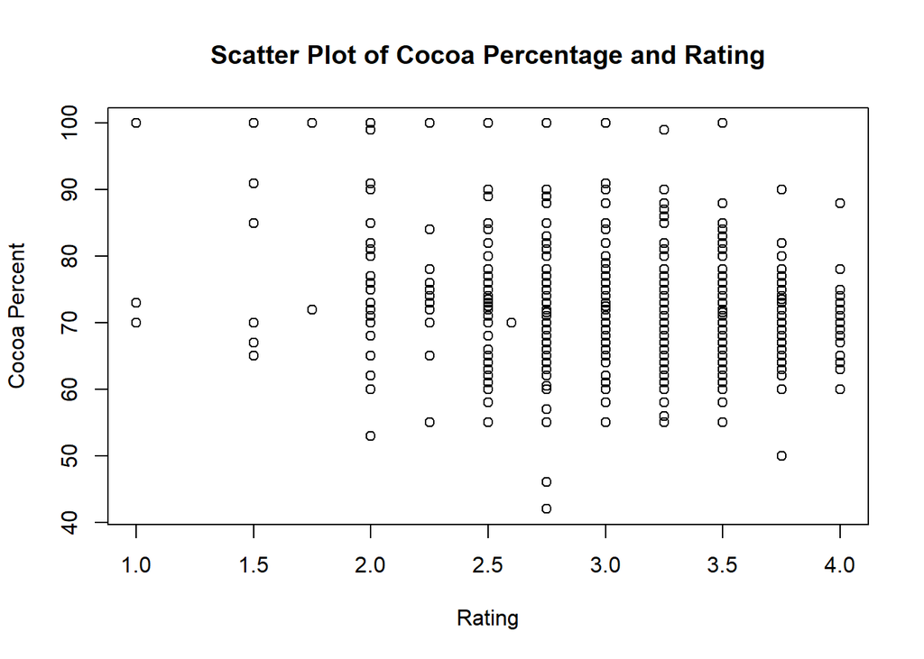

```r
plot(choco$Rating, choco$Cocoa_Percent, main='Scatter Plot of Cocoa Percentage and Rating', xlab='Rating', ylab='Cocoa Percent')
```

A scatterplot is definetely not the best idea here as we see that we’re getting something more along the lines of a dot plot and not really seeing how chocolates are distributed over rating and cocoa percent.

# Question 1.4

How do different bean origins compare in terms of the flavor of chocolates? Are beans from some places better than the other? Create both numerical and graphical summaries, and explain.

```r
or <- choco[,c("Bean_Origin", "Rating")]
table(or)
```

```
##                        Rating
## Bean_Origin              1 1.5 1.75  2 2.25 2.5 2.6 2.75  3 3.25 3.5 3.75  4
##   Australia              0   0    0  0    0   0   0    1  0    1   0    1  0
##   Belize                 0   0    0  0    0   1   0    9 17   18  14    6  2
##   blend                  0   0    0  0    0   0   0    0  1    0   0    0  0
##   Blend                  3   5    0 11    0   9   0   20 30   21  27   18  7
##   Bolivia                0   0    0  1    0   7   0    9 17   15  10    8  5
##   Bolvia                 0   0    0  0    0   0   0    0  0    1   0    0  0
##   Brazil                 0   0    1  0    0   3   0    8 18   12  20    9  4
##   Burma                  0   0    0  0    0   0   0    0  1    0   0    0  0
##   Cameroon               0   0    0  0    0   0   0    0  2    1   0    0  0
##   Colombia               0   0    0  1    0   3   0   11 16   13   9    8  5
##   Congo                  0   0    0  0    0   0   0    1  2    3   3    2  0
##   Costa Rica             0   0    0  1    0   3   0    5 12    9   9    2  2
##   Cuba                   0   0    0  0    0   1   0    1  2    2   3    3  0
##   Dominican Republic     0   0    0  1    2  11   1   28 46   42  39   36  0
##   DR Congo               0   0    0  0    0   0   0    0  1    0   0    0  0
##   Ecuador                1   3    0  6    0  22   0   24 31   37  56   24  8
##   El Salvador            0   0    0  0    0   0   0    2  2    2   0    0  0
##   Fiji                   0   0    0  0    0   2   0    3  3    4   2    1  0
##   Gabon                  0   0    0  0    0   0   0    0  0    1   0    0  0
##   Ghana                  0   1    0  1    0   4   0    5  9    2   9    4  2
##   Grenada                0   0    0  0    1   3   0    5  0    4   6    0  0
##   Guatemala              0   0    0  0    0   1   0    8 10   10  17    4  3
##   Haiti                  0   0    0  0    0   1   0    4  4    4   8    0  3
##   Honduras               0   0    0  0    0   1   0    5  2    5   7    3  0
##   India                  0   0    0  0    0   2   0    1  6    6   6    0  0
##   Indonesia              0   0    0  0    1   2   0    4  3    2   2    3  1
##   Ivory Coast            0   0    0  0    0   2   0    0  3    0   0    0  0
##   Jamaica                0   0    0  1    0   1   0    3  5    7   1    4  1
##   Liberia                0   0    0  0    0   0   0    1  0    2   0    0  0
##   Madagascar             0   0    0  0    1   5   0   23 40   21  44   19 10
##   Malaysia               0   0    0  0    0   1   0    1  2    2   1    0  0
##   Martinique             0   0    0  0    0   0   0    1  0    0   0    0  0
##   Mexico                 0   0    0  1    0   6   0    6 12    9   5    4  3
##   Nicaragua              0   0    0  1    0   4   0   13 15   21  24   12  2
##   Nigeria                0   0    0  0    0   0   0    1  1    1   0    0  0
##   Panama                 0   0    0  0    0   0   0    2  2    1   3    0  0
##   Papua New Guinea       0   0    0  0    0   2   0    5 12    9  14    3  4
##   Peru                   0   1    0  2    6  25   0   30 41   30  43   26 16
```

[output cut: 10 more lines]

```
##   St.Vincent-Grenadines  0   0    0  0    0   0   0    1  0    0   0    0  0
##   Sulawesi               0   0    0  0    0   0   0    0  0    1   0    0  0
##   Sumatra                0   0    0  0    0   0   0    0  1    0   0    0  0
##   Suriname               0   0    0  0    0   0   0    0  0    1   0    0  0
##   Taiwan                 0   0    0  0    0   1   0    0  0    1   0    0  0
##   Tanzania               0   0    0  2    0   2   0    8 12   16  13   10  1
##   Thailand               0   0    0  0    0   0   0    1  1    0   2    1  0
##   Tobago                 0   0    0  0    0   0   0    0  0    1   0    0  1
##   Togo                   0   0    0  0    0   0   0    1  1    0   1    0  0
##   Trinidad               0   0    0  0    0   3   0    6  6    6  12    5  0
##   U.S.A.                 0   0    0  1    0   2   0    3  6    5   7    6  0
##   Uganda                 0   0    0  0    0   4   0    4  1    0   1    1  0
##   Vanuatu                0   0    0  0    0   1   0    4  3    1   1    3  0
##   Venezuela              0   0    1  3    3  17   0   29 59   29  50   36 18
##   Vietnam                0   0    0  0    0   0   0    8 15   15  21    4  1
```

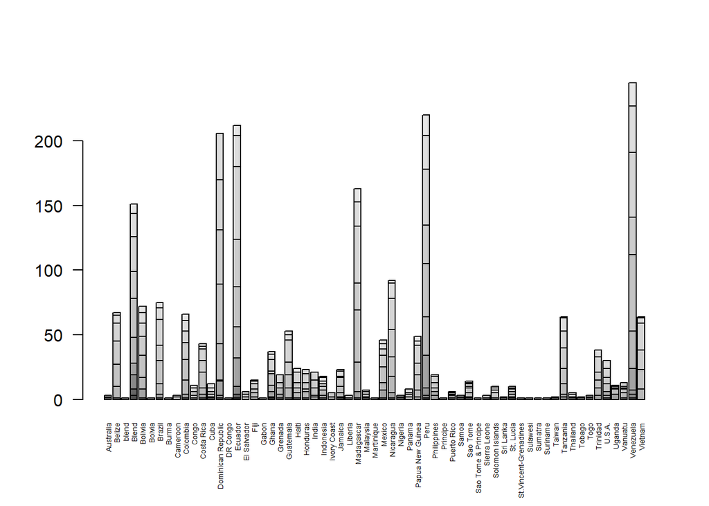

```r
origin_counts <- table(choco$Rating, choco$Bean_Origin)
barplot(origin_counts, las=2, cex.names=0.45)
```

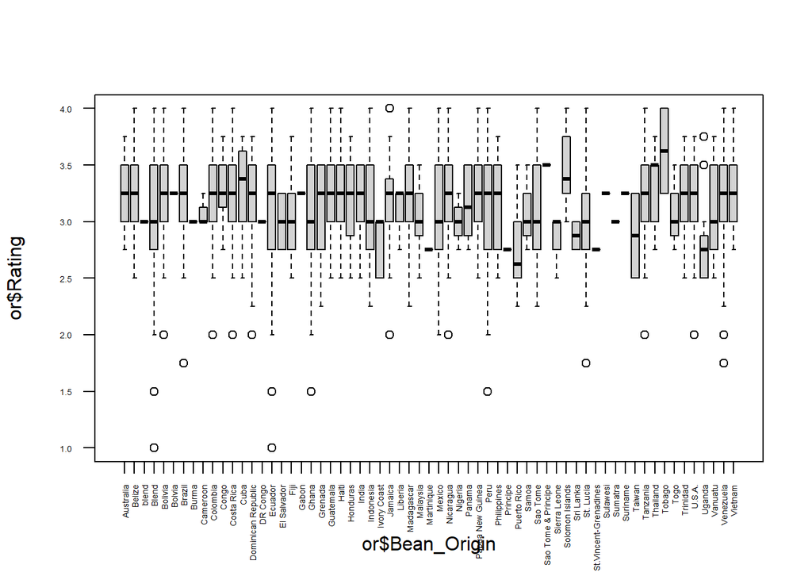

```r
origin_by_rating <-  or$Rating ~ or$Bean_Origin
boxplot(origin_by_rating, las=2, cex.axis=0.45)
```

# Question 1.5

Brainstorm two analyses you would like to perform (with your teammates). Describe in plain language what comparisons are you making. Create suitable numerical and graphical summaries for your analyses. Describe the results.

### # Analysis 1: How are cocoa beans rated based on origin?

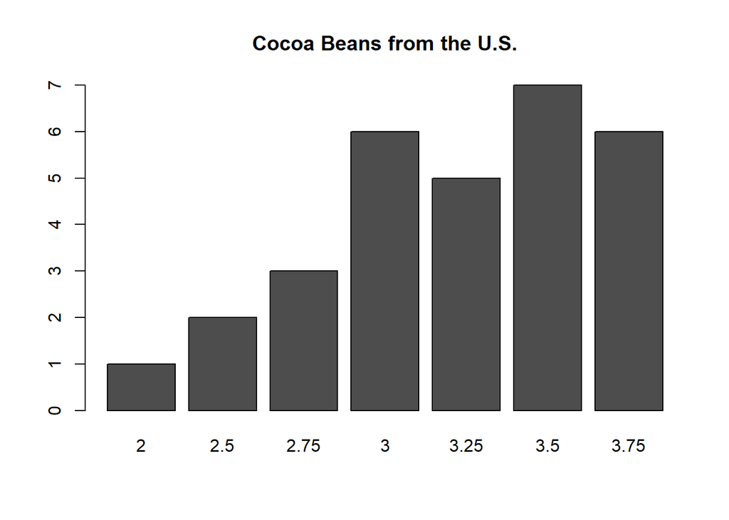

```r
rows <- choco[choco$Bean_Origin == "U.S.A.", ]
barplot(table(rows[, "Bean_Origin"], rows[, "Rating"] ), main = "Cocoa Beans from the U.S.")
```

```r
print(summary(rows[, "Rating"]))
```

```
##    Min. 1st Qu.  Median    Mean 3rd Qu.    Max.
##   2.000   3.000   3.250   3.217   3.500   3.750
```

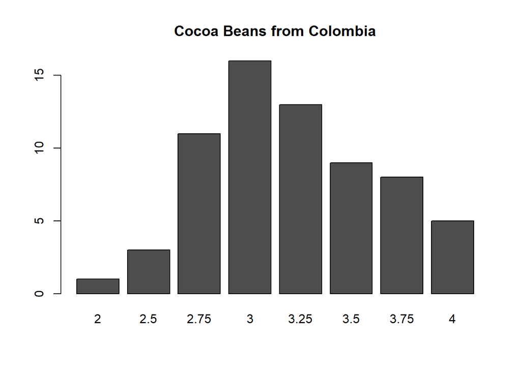

```r
rows2 <- choco[choco$Bean_Origin == "Colombia", ]
barplot(table(rows2[, "Bean_Origin"], rows2[, "Rating"] ), main = "Cocoa Beans from Colombia")
```

```r
print(summary(rows2[, "Rating"]))
```

```
##    Min. 1st Qu.  Median    Mean 3rd Qu.    Max.
##   2.000   3.000   3.250   3.205   3.500   4.000
```

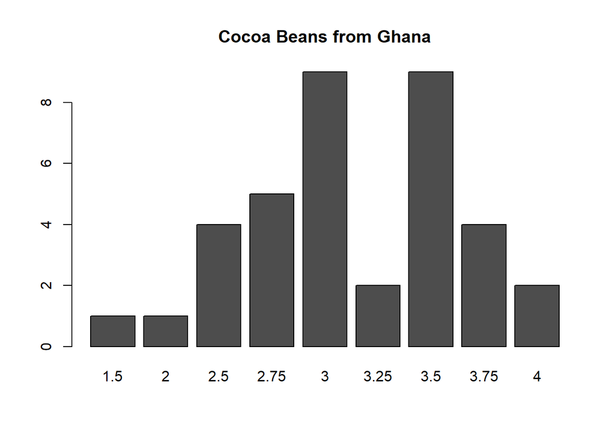

```r
rows3 <- choco[choco$Bean_Origin == "Ghana", ]
barplot(table(rows3[, "Bean_Origin"], rows3[, "Rating"] ), main = "Cocoa Beans from Ghana")
```

```r
print(summary(rows3[, "Rating"]))
```

```
##    Min. 1st Qu.  Median    Mean 3rd Qu.    Max.
##   1.500   2.750   3.000   3.115   3.500   4.000
```

### Analysis 2: What years had the highest-rated chocolate?

First, lets check the amount of ratings per year.

```r
yr <- choco[,c("Date", "Rating")]

year_counts <- table(choco$Rating, choco$Date)
table(yr)
```

```
##       Rating
## Date    1 1.5 1.75  2 2.25 2.5 2.6 2.75  3 3.25 3.5 3.75  4
##   2006  1   2    0 10    0   3   0    2 19    1   8   12  4
##   2007  2   1    0  4    0   8   0    2 23    3  15    7  8
##   2008  1   1    0  5    0  11   0   16 27    3  17    9  2
##   2009  0   1    1  4    0   6   0   23 42   14  16   12  4
##   2010  0   1    1  1    2   5   0   19 24   19  19   16  3
##   2011  0   2    0  2    1  10   0   22 22   28  38   23 15
##   2012  0   2    0  3    1  21   0   24 30   39  39   24 11
##   2013  0   0    1  0    3  15   0   30 27   41  36   18 13
##   2014  0   0    0  1    4  19   0   38 44   46  58   31  6
##   2015  0   0    0  1    2  12   0   40 47   61  80   33  8
##   2016  0   0    0  1    1  15   0   37 34   41  48   33  9
##   2017  0   0    0  0    0   2   0   10 12   23  36   17  5
##   2018  0   0    0  1    1  14   1   22 72   41  46   19 11
##   2019  0   0    0  0    2  17   0   27 57   35  38   16  3
##   2020  0   0    0  0    0   1   0    5  8   10   9    0  0
```

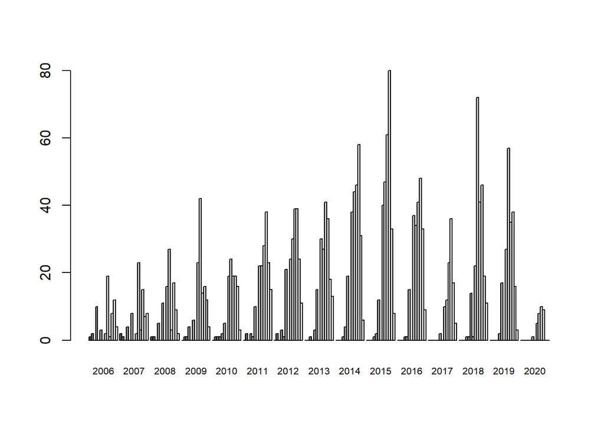

```r
barplot(year_counts, cex.names=0.65, beside=TRUE)
```

Next, lets look at 2 box plots; the first is shows how each rating is dispersed across all years, and the second shows all of the ratings for each year.

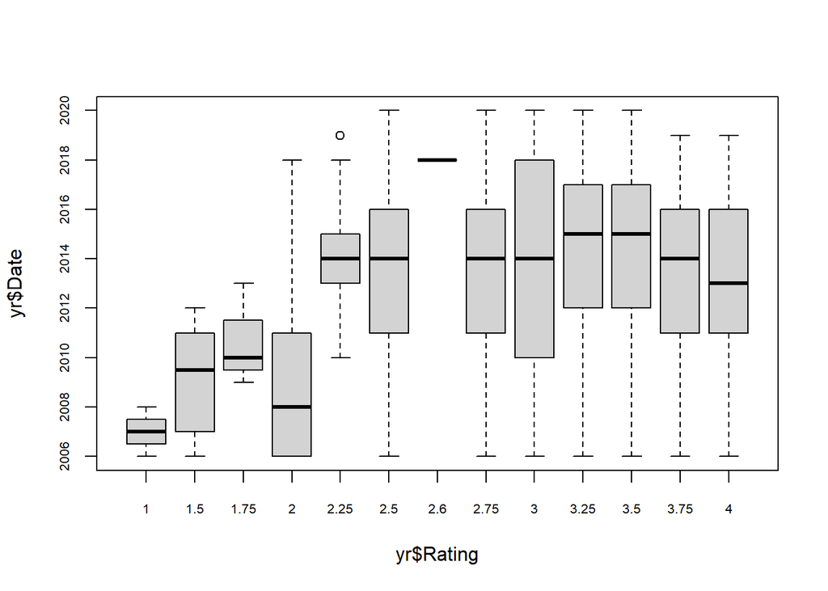

```r
origin_by_rating <-  yr$Date ~ yr$Rating
boxplot(origin_by_rating, cex.axis=0.65)
```

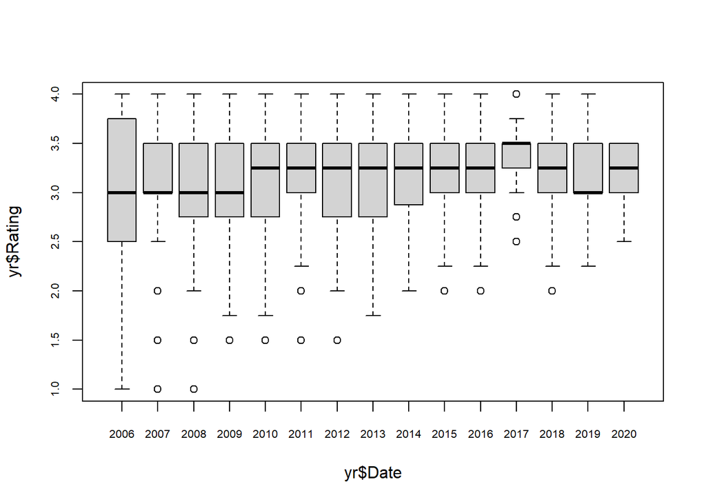

```r
origin_by_rating <-  yr$Rating ~ yr$Date
boxplot(origin_by_rating, cex.axis=0.65)
```